# SIDA and SIDANet

# Correlation Plots

We also provide the function *CorrelationPlots()* for visualizing correlations between estimated discriminant vectors. Here’s an example graph with two classes and views moderately correlated. Correlation estimate is given in absolute value.

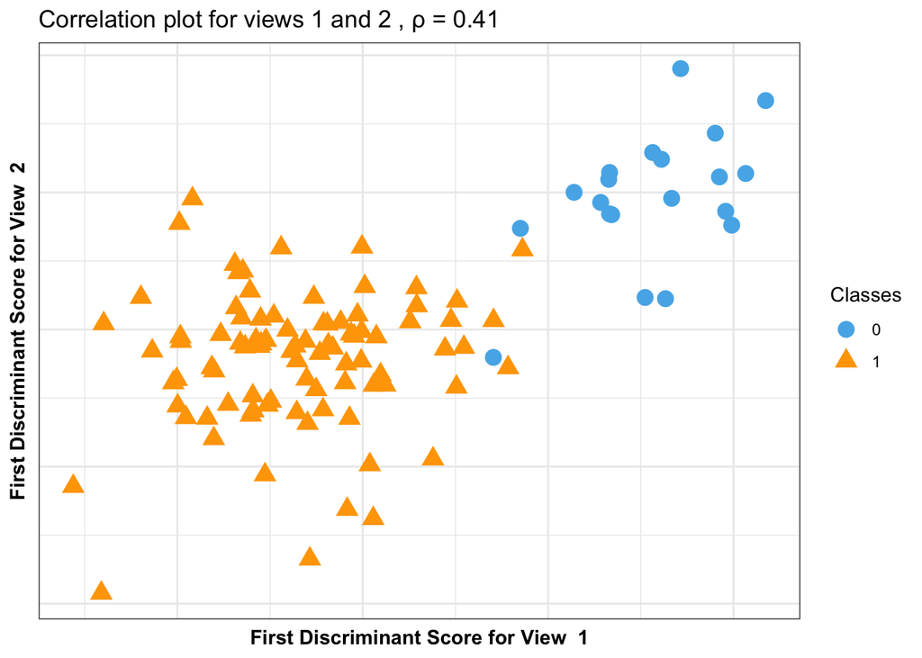

```r
Xdata1 <- filterOmics$X[[1]]
Xdata2 <- filterOmics$X[[2]]
Y=filterOmics$Y
Xdata=list(Xdata1, Xdata2)

CorrelationPlots(Xdata, Ytest=Y, fit.cvsida$hatalpha)
```

```r
#We notice that the views are moderately correlated, and the classes are well-separated.
```

# Relevance Network Plot

We provide the function *networkPlot()* to visualize associations of selected variables between pairs of views. We estimate pairwise similarity matrix using low-dimensional representations of our sparse integrative analysis methods (selpcca, sida, sidanet). We create bipartite graph (bigraph) where variables or nodes from one view are connected to variables or nodes from another view. We construct the bigraph from a pairwise similarity matrix obtained from the outputs of our integrative analysis methods. We estimate the similarity score between a pair of selected variables from two views by calculating the inner product of each selected variable and the sum of canonical variates (for SELPCCA) or discriminant vectors (for SIDA, SIDANet) for the pairs of views. The entries in the similarity matrix is a robust approximation of the Pearson correlation between pairs of variables and the two views under consideration. This network graph has potential to shed light on the complex associations between pairs of views.

Variable pairs with high similarity score may be of interest. The relevance of the associations can be explored by changing the cutoff. This can also be used to reduce the size of the graph, for dense network.

By default, dashed lines indicate negative associations and solid lines represent positive associations.

```r
dev.off()
```

```r
networkPlot(fit.cvsida,cutoff=.1)


#The plot suggest that the gene FAM3D is negatively  correlated with many proteins (e.g. PO2766, P30491, Q08380), and positively correlated with proteins such as A0ADC4DFP6, E9PEK4, P04196, D6W5L6.
```

[output not shown]

Demonstration of *cvSIDANet()*

The function *cvSIDANet()* incorporates prior structural information (e.g. gene-gene connectivity) in SIDA via the use of the normalized Laplacian of graph, thus encouraging selection of predictors that are connected and behave similarly.

Covariates, if available, can be included. We provide the option to select or force covariates in the models. To select covariates (or shrink weights of some covariates to zero), set *withCov = FALSE*. To force weights of covariates to not be shruck to zero, set *withCov = TRUE*. Unlike *cvselpscca()*, *cvSIDA()* or *cvSIDANet()* is applicable to two or more views.

We demonstrate the use of *cvSIDANet()* on simulated data.

```r
data("sidanetData")
Xdata <- sidanetData[[1]]
Y <- sidanetData[[2]] #class membership already coded as 1,2,...
Xtestdata <- sidanetData[[3]]
Ytest <- sidanetData[[4]] #class membership already coded as 1,2,...

#edge information
myedges=sidanetData[[5]]
myedgeweight=sidanetData[[6]]

 ##---- call cross validation
mycvsidanet=cvSIDANet(Xdata,Y,myedges,myedgeweight,withCov=FALSE,plotIt=FALSE,Xtestdata=Xtestdata,
     Ytest=Ytest)
```

```
## [1] "Getting tuning grid values"
## [1] "Completed at time"
## Time difference of 5.376648 secs
## Begin 5 -folds cross-validation
## [1] "Cross-validation completed at time"
## Time difference of 2.10649 mins
## [1] "Getting Results......"
## Estimated Test Classification Error is 0.03333333
## Estimated Train Classification Error is 0.04166667
## Estimated Test Correlation is 0.8870161
## Estimated Train Correlation is 0.8994912
## Number of nonzero coefficients in view 1 is 20
## Number of nonzero coefficients in view 2 is 111
## Number of nonzero coefficients in view 1 is 40
## Number of nonzero coefficients in view 2 is 222
## [1] "Total time used is"
## Time difference of 2.435557 mins
```

And here’s an example plot with three classes

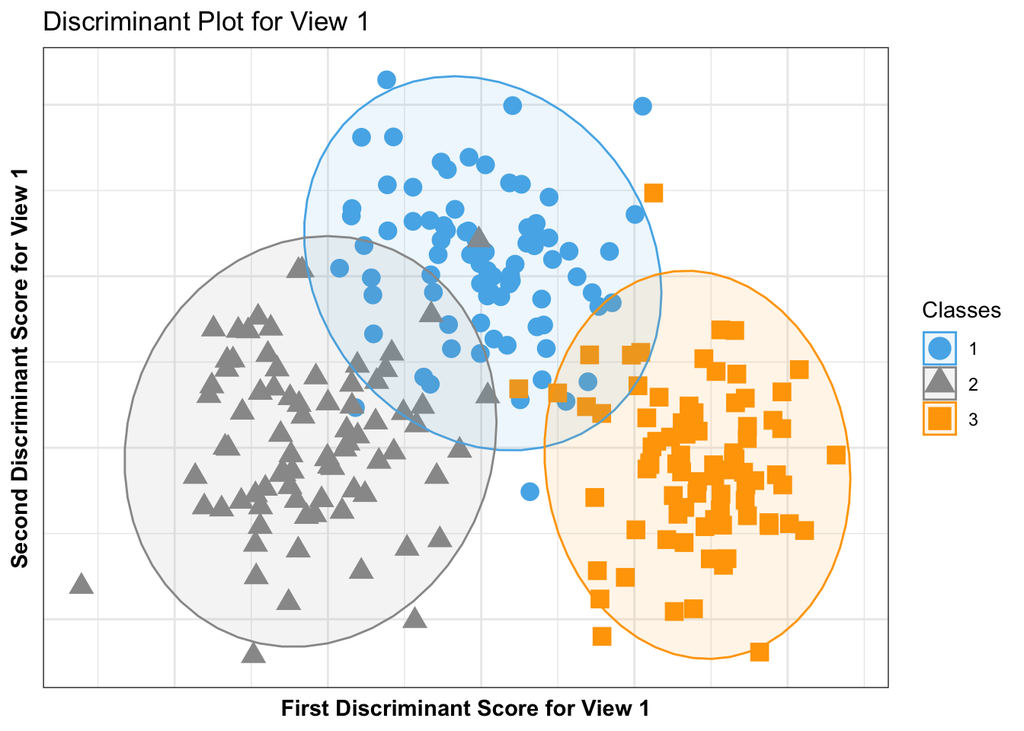

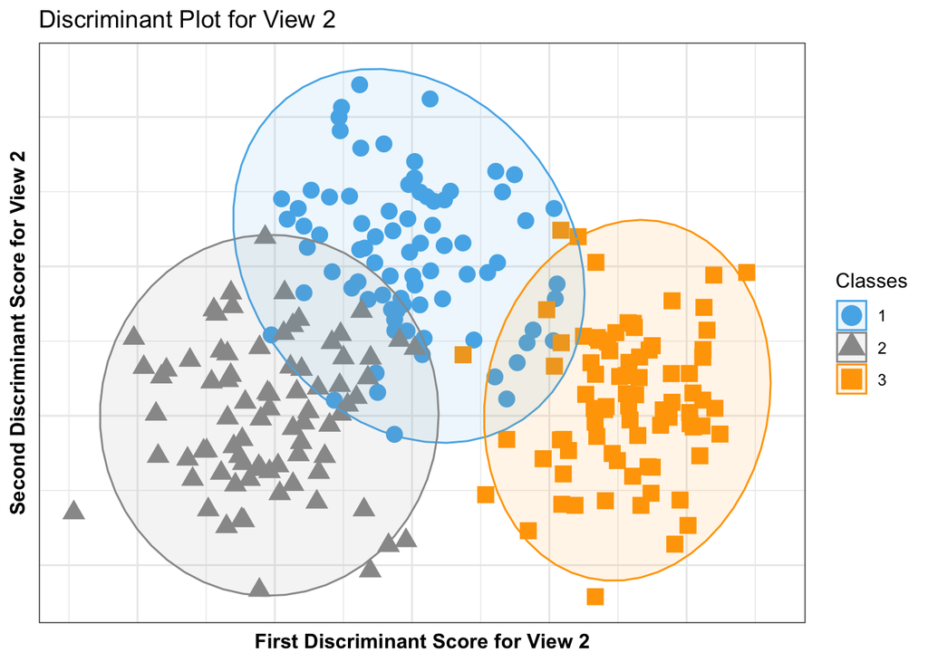

```r
Xdata <- sidanetData[[1]]
Y <- sidanetData[[2]]

DiscriminantPlots(Xdata, Y, mycvsidanet$hatalpha, method.used = "SIDA")
```

And here’s an example correlation plot with three classes where the first canonical correlation is high, suggesting that the two views are highly associated.

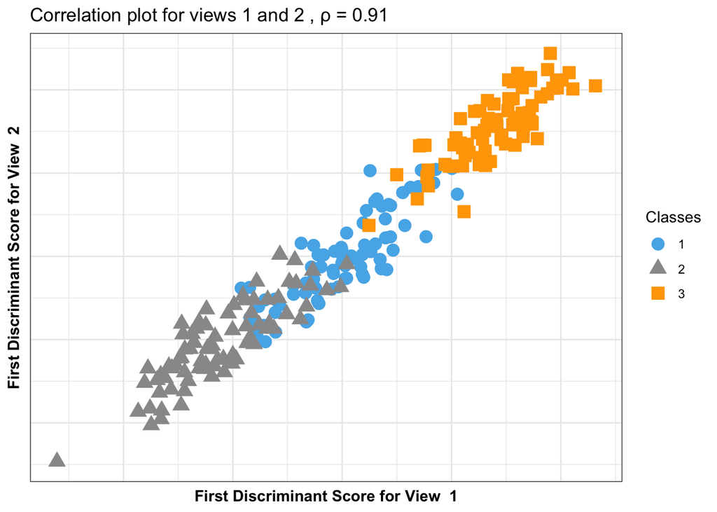

```r
Xdata <- sidanetData[[1]]
Y <- sidanetData[[2]]

CorrelationPlots(Xdata, Y, mycvsidanet$hatalpha, method.used = "SIDA")
```

# Loadings Plots

We provide the function *LoadingsPlot()* to plot discriminant and canonical correlation vectors. These graphs are useful for visualizing how selected variables from SIDA/SIDANet contribute to the first and second discriminant.

Variables farther from the origin and close to the first or second axis have higher impact on the first or second discriminant/canonical vectors, respectively.

Variables farther from the origin and between both first and second axes have similar higher contributions to the first and second discriminant/canonical correlation vectors.

In both situations, for SIDA and SIDANet, this suggests that these variables contribute more to the separation of classes and association of views. This plot can only be generated for classification and association problems with 3 or more classes.

The angle between two vectors also give an indication of how the two variables are correlated. In particular, vectors that are close to each other suggest that the variables have high positive correlation. Vectors that are about 90 degrees indicate that the two variables are uncorrelated. Vectors that have an angle close to 180 degrees indicate that the two variables have negative correlation.

In order not to clutter the graph, we provide the option *keep.loadings* for the number of variables with highest absolute weights to show on the graph for each view.

Here’s the loadings plot for results from CVSIDANet In this example, we show the top 7 variables with largest absolute weights on the plot for view 1 and top 3 for view 2

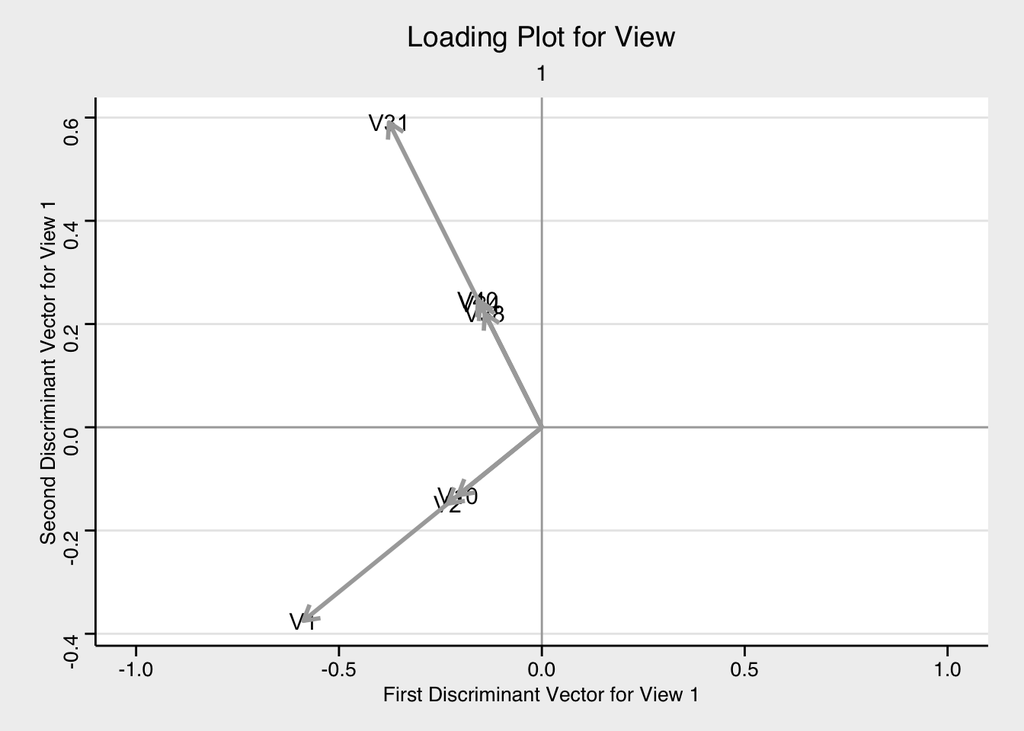

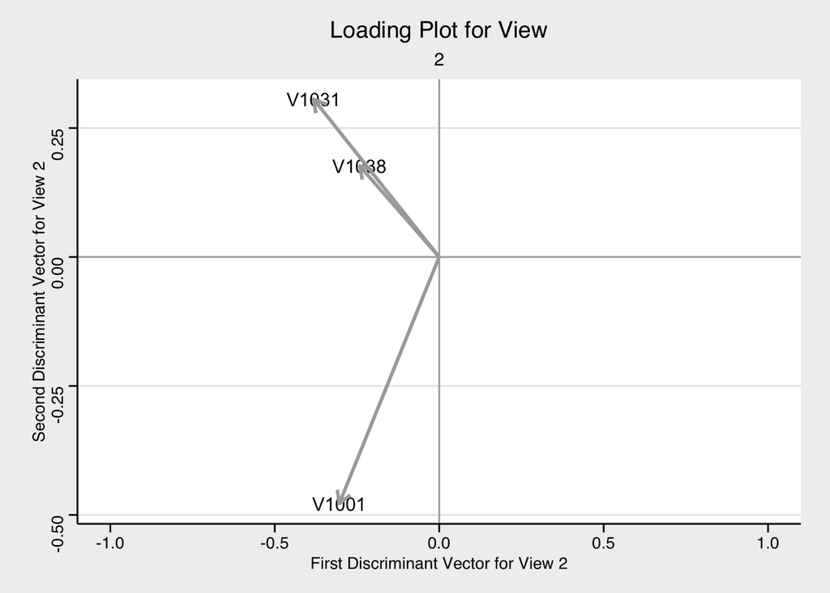

```r
LoadingsPlots(mycvsidanet,keep.loadings=c(7,3))
```

# Biplots

Biplots are useful for representing both loadings plot and discriminant scores/canonical correlation variates.

We provide the function *WithinViewBiplot()* to visualize the scores and loadings for each view separately.

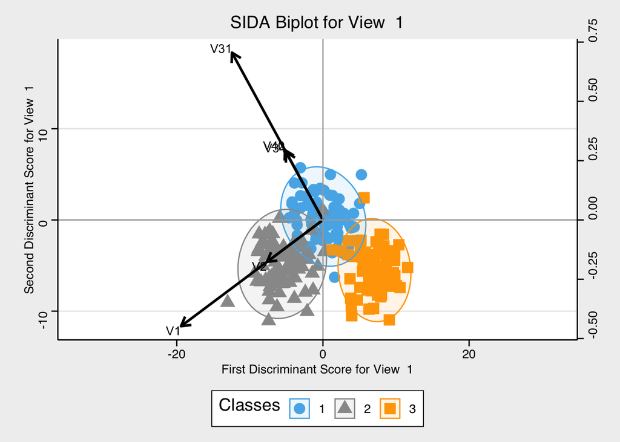

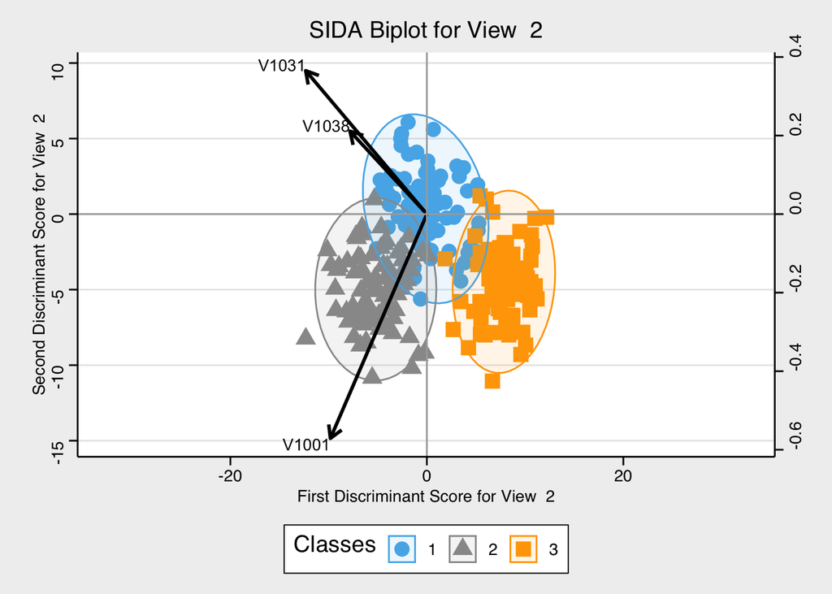

```r
WithinViewBiplot(mycvsidanet,Y,Xtest=NULL,keep.loadings = c(5,3))
```

Now, instead of visualizing biplots separately for each view, we provide the function *BetweenViewBiplot()* to graph scores and loadings for pairs of views.

In this graph, dashed red vectors represent loadings plot for the second view. And solid black vectors represent loadings plot for the first view.

The scores are the sum of scores for the two views.

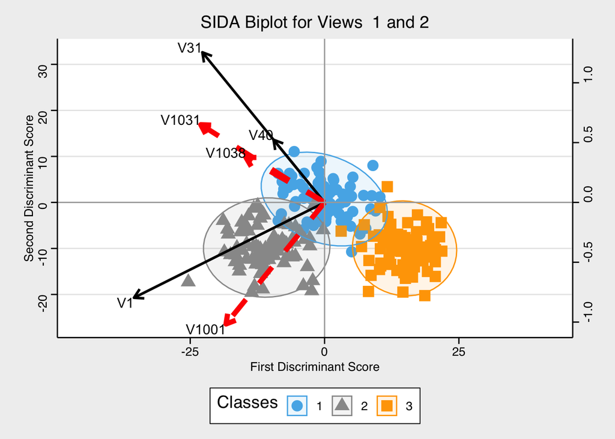

```r
BetweenViewBiplot(mycvsidanet,Y,Xtest=NULL, keep.loadings = c(3,3))
```